# RPG

B. Maranget

08/01/2021

# 1 Cadre

## 1.1 Objet

agréger contenu rpg de parcelles à canton

## 1.2 Librairies et répertoire

```r
library(sf)
```

```r
library(cartography)
```

# 2 Données

```r
# communes sans la corse
commune <- st_read("../dataE/00_ADMIN/ign.gpkg", "commune", quiet = TRUE,stringsAsFactors = F)
dpt <- st_read("../dataE/00_ADMIN/ign.gpkg", "dpt", quiet = TRUE, stringsAsFactors = F)
# Ouverture des 100 premières lignes de fichier des parcelles
dataTest <- st_read("../dataE/01_CULTURES/PARCELLES_GRAPHIQUES.gpkg", "parcelle_graphique",
    query = 'SELECT * FROM "parcelle_graphique" LIMIT 100' )
# liste des variables culture année 2017 (ancien fichier résultat)
culture <- read.csv("../dataE/01_CULTURES/culture.csv", header = FALSE, stringsAsFactors = FALSE)
culture <- culture$V1
# 297 colonnes 280 d'origigine et rajout col avec 8
canton2015 <- st_read("../dataE/00_ADMIN/CANTON.SHP")
```

# 3 Récupération des données du fichier des parcelles

## 3.1 Ouverture

Le fichier comporte 9 millions de parcelles, il ne s’ouvre pas en totalité sous R.

On pourrait l’ouvrir via une boucle sur chaque code culture

```r
i <- 1
query_str <- paste0('SELECT ID_PARCEL, geom FROM "parcelle_graphique" WHERE CODE_CULTU = "', culture [i], "\"")
data <- st_read("../dataE/01_CULTURES/PARCELLES_GRAPHIQUES.gpkg", "parcelle_graphique", query = query_str)
inter <- st_intersection(canton2015 [,"CODE_CANT"], data [,"ID_PARCEL"])
```

On pourrait l’ouvrir sans la géométrie

```r
#  téléchargement du fichier sans la géomtrie
dataSansGeom <- st_read("../dataE/01_CULTURES/PARCELLES_GRAPHIQUES.gpkg", "parcelle_graphique",
  query = 'SELECT  ID_PARCEL , CODE_CULTU , CODE_GROUP FROM "parcelle_graphique" ' )
```

On préfère mettre en place une base postgis et on fait l’agregation dedans.

```sql
CREATE TABLE lien AS (
SELECT canton.fid, code_cultu, sum(surf_parc)  AS surface
FROM parcelle_graphique, canton
    WHERE ST_INTERSECTS(st_centroid(parcelle_graphique.geom), canton.geom)
    GROUP BY code_cultu, canton.fid
    );
```

TODO explorer diply et sqllite

La table contient donc toutes les données du fichier. Pour alléger, on a enlevé les géométries à l’export mais l’intersection s’est fait sur les géométries L’identifiant (fid) correspond aux derniers chiffres de l’identifiant géofla.

TODO pourquoi cette multiplicité d’identifiants ?

## 3.2 Création d’un identifiant simple

```r
data <- read.csv("../dataS/lien.csv", sep = "\t", dec = ".", header  = FALSE)
#  106 660 lg
names(data) <- c("ID_CANTON", "CULTURE", "SURFACE")
table(data$CULTURE)
```

```
##
##  AGR  AIL  ANE  ANG  ANI  ARA  ART  AUB  AVH  AVO  AVP  BAR  BAS  BDH  BDP  BFP
##   65  283   40   32    7    5  191  145 1371    6 1374   13   36 1085  307 1108
##  BFS  BLT  BOP  BOR  BRH  BRO  BTA  BTH  BTN  BTP  BUR  BVF  CAB  CAE  CAF  CAG
## 1285   36 1417 1607   14  102 1886 2086  831 1004    2  950    2   42    9  312
##  CAR  CAV  CBT  CCN  CCT  CEE  CEL  CES  CGF  CGH  CGO  CGP  CHA  CHF  CHH  CHR
##  593    4   55  142  481   59  216  282    9   15   69   49   50  212   44   24
##  CHS  CHT  CHU  CHV  CIB  CID  CIT  CMB  CML  CMM  CNE  CPA  CPH  CPL  CPS  CPT
##   22  283  482  291   33  117   35  503  140   55    1   64   15  742    1   40
##  CPZ  CRD  CRF  CRN  CRS  CSE  CSS  CTG  CUM  CZH  CZP  DOL  DTY  EPE  EPI  EST
##    6  123   12    1   14   83  257  262    2 1761  245    2  701  957  168   28
##  FAG  FET  FEV  FFO  FLA  FLO  FLP  FNO  FNU  FRA  FSG  FVL  GES  GFP  HAR  HBL
## 1114  771  116  403 1758   35  982  102  103  704  431 1293   45  344  648   79
##  J5M  J6P  J6S  JNO  JOS  LAV  LBF  LDH  LDP  LEC  LEF  LFH  LFP  LIF  LIH  LIP
## 1883 1735 1745   79    5  176  361  112  176  810   43   48   66  320  393  430
##  LOT  LUD  LUZ  MAC  MAV  MCR  MCT  MED  MEL  MID  MIE  MIN  MIS  MLC  MLD  MLF
##   77  329 1925   67   17 1433  605    2   61  205 1681    8 1924 1142   16 1165
##  MLG  MLI  MLO  MLP  MLT  MOH  MOL  MOT  MPA  MPC  MPP  MRG  MRJ  MRS  MTH  NOS
## 1707   66  324   16  343  438   27  527  162 1014  223    7   60   10  112  278
##  NOX  NVE  NVF  NVH  NVT  NYG  OAG  OEH  OEI  OHN  OHR  OIG  OLI  OPN  OPR  ORH
##  489   22   25   17  161    5   66    7  103    1    5  711  260    3    6 2021
##  ORP  ORT  OSE  PAG  PAN  PAQ  PAS  PAT  PCH  PCL  PEP  PFH  PFP  PFR  PHI  PIS
## 1756   34   17   26   94    5   64   28  620  370  701  305  356  738  795   12
##  PMV  POR  POT  PPA  PPH  PPO  PPP  PPR  PRL  PRU  PSE  PSL  PSN  PSY  PTC  PTF
##    3  387  420  549 2225  478  660 1045 1960   77    4  187   10   13 1657  191
##  PTR  PVP  PVT  PWT  RDF  RDI  RGA  RIZ  ROM  ROQ  ROS  RUT  RVI  SAD  SAI  SBO
## 2106  138   16   58   66  232 1567   18   69   24   62   21  325   25  483 1323
##  SER  SFI  SGE  SGH  SGP  SNE  SOG  SOJ  SPH  SPL  SRI  SRS  TAB  TCR  THY  TOM
##    2   26   90 1104  160 2177 1336  980 1053  653   48 1002  181  516  158  428
##  TOP  TOT  TRD  TRE  TRN  TRU  TTH  TTP  VAL  VED  VER  VES  VRC  VRG  VRN  VRT
##  132   82   52 1489 1269  535 1705  301    6    9    2  460  958 1628  608  580
##  XFE
##   24
```

```r
# simplification de l'identifiant geofla
canton2015$ID_CANTON <- as.integer(substring(canton2015$ID_GEOFLA, 21,29))
# verif identiant unique 2378 cantons.
length(unique(canton2015$ID_CANTON))
```

```
## [1] 2378
```

## 3.3 Calcul de la SAU pour toutes les cultures pour chaque canton

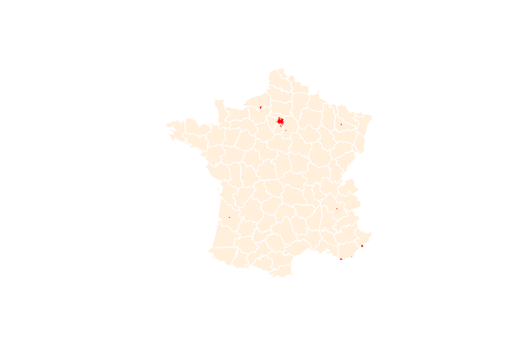

```r
SAU <-  aggregate(data$SURFACE, by = list (data$ID_CANTON), sum)
names(SAU) <- c("ID_CANTON", "SAU_HA")
canton2015b <- merge(canton2015, SAU, by = "ID_CANTON")
# 2281 cantons avec une SAU contre 2378 cantons au total
diff <- setdiff(canton2015$ID_CANTON,canton2015b$ID_CANTON)
cantondiff <- canton2015 [canton2015$ID_CANTON %in% diff,]
plot(dpt$geom, col = "antiquewhite1", border = "white")
plot(cantondiff$geometry, add = TRUE, col= "red", border = NA)
```

```r
canton2015 <- canton2015b
```

Il y 97 cantons sans culture.

TODO analyse canton sans culture ?

TODO pb surface bio inclu dans SAU ?

## 3.4 Vérification import données

Pour vérification, on va extraire de la table le CAE via R

```r
cae <- st_read("../dataE/01_CULTURES/PARCELLES_GRAPHIQUES.gpkg", "parcelle_graphique",
    query = 'SELECT * FROM "parcelle_graphique" WHERE CODE_CULTU = "CAE"')
st_write(cae, "../dataS/rpg.gpkg", "cae", delete_layer = TRUE, quiet = TRUE)
head(cae)
cae.c <- st_centroid(cae)
caeCantonInter <- st_intersection(cae, canton2015)
nrow(caeCantonInter) - nrow(cae)
# 41 morceaux de parcelles sur 2634.
str(caeCantonInter)
# verif des aires
caeCantonInter$aire <- round(st_area(caeCantonInter)/10000,2)
caeCantonInter$aire <- as.numeric(caeCantonInter$aire)
caeCantonInter$verif <- caeCantonInter$SURF_PARC - caeCantonInter$aire
plot((caeCantonInter$verif))
# 91 aires différentes
caeCantonAire <-caeCantonInter [, c("aire", "ID_GEOFLA"), drop = FALSE]
caeCantonAgg <- aggregate(aire~ID_GEOFLA,caeCantonAire, sum)
# on rattache les géométries des cantons.
caeData <- merge(caeCantonAgg, canton2015, by = "ID_GEOFLA")
caeData <- st_as_sf(caeData)
choroLayer(caeData, var ="aire")
st_write(caeData, "../dataS/rpg.gpkg", "verifCAE", quiet = TRUE, delete_layer = TRUE)

dataCAE <- data [data$CULTURE == "CAE",]

st_write(dataCAE, "../dataS/rpg.gpkg", "baseCAE", quiet = TRUE, delete_layer = TRUE)
```

Il y a de légères différences dûes à l’utilisation du centroid dans la requete sql.

TODO vérification sur les quantités totales de culture

# 4 Catégories de culture

## 4.1 Problème : pas toutes les variables dans le rpg 2019

```r
dataCulture <- names (table(data$CULTURE))
diff <- setdiff(culture, dataCulture)
# exclusion 10 codes
setdiff(dataCulture, culture)
```

```
##  [1] "BUR" "CNE" "CRN" "CSE" "CUM" "MLC" "MLF" "MPP" "OPN" "VRN"
```

```r
cultureDef <- intersect(culture,dataCulture)
# cultureDef représente les champs présents dans les deux tables (231)
# on filtre ensuite sur les cultures nécessaires uniquement
dataFiltre <- data [data$CULTURE %in% cultureDef,]
# 103 430 lg. -3 000 c'est toujours bon à prendre
```

## 4.2 Vérification code culture possible entre fichier sans geom et lien

```r
#  téléchargement du fichier sans la géomtrie
dataSansGeom <- st_read("../dataE/01_CULTURES/PARCELLES_GRAPHIQUES.gpkg", "parcelle_graphique",
  query = 'SELECT  ID_PARCEL , CODE_CULTU , CODE_GROUP FROM "parcelle_graphique" ' )
cultureSansGeom <- names(table(dataSansGeom$CODE_CULTU))
setdiff(cultureSansGeom, vCulture)
```

[output not shown]

Donc les données sont sûres….

# 5 Mise en forme des données

Le tableau final comporte une transposition de la colonne en ligne.

## 5.1 Transpostion données colonne ligne

```r
# création df nb de lg = nb de cantons et nb de col = nb de cultures + Canton
df <- data.frame(matrix
                    (vector(),
                    2281,232,
                    dimnames = list(c(), c("ID_CANTON",cultureDef))
                    ),
                 stringsAsFactors = F)
# parcours de dataFiltre
df$ID_CANTON <- unique(data$ID_CANTON)
nb <- length(dataFiltre$ID_CANTON)
i <- 1
for (i in 1:nb) {
  surface <- dataFiltre$SURFACE [i]
  canton <- dataFiltre$ID_CANTON [i]
  culture <- dataFiltre$CULTURE [i]
  df [df$ID_CANTON == canton ,  culture] <- surface
}
# verif : compter les totaux
sum(df [,-1], na.rm = TRUE)
```

```
## [1] 27843562
```

```r
sum(dataFiltre$SURFACE)
```

```
## [1] 27843562
```

## 5.2 Fusion avec colonnes finales

```r
# on fait la jointure avec les géométries des cantons
dfFusion <- merge(canton2015, df, by = "ID_CANTON")
# 2281
# pour fichier final
col <- c("Code_canto",  "NOM_CHF", "CODE_DEPT", "NOM_DEPT", "CODE_REG","NOM_REG", "CODE_CANT", "SAU_HA", cultureDef)
dfFusion <- dfFusion [, col]
st_write(dfFusion, "../dataS/rpg.gpkg", "dataFinale", quiet = TRUE, delete_layer = TRUE)
# export des données alpha numériques uniquement
dfSansGeom <- dfFusion [, col, drop = TRUE]
write.csv2(dfSansGeom, "../dataS/dataFinale.csv", na = "" , row.names = FALSE)
# 2281 lignes
```